# Disposition Summary

2024-02-29

## Data Details and Insights

The following dataset contains information candidate’s **Disposition Ratings**. Students and educators are required to abide by the criteria, as well as understand concepts and practice while being rated by instructions in selected program classes.

## Survey Questionnaire

The rubric consists of 8 questions with the possible answers being: `Unacceptable`, `Developing`, `Proficient`, `Exemplary`, and `Not Observed`. Answers without response will be marked as `NA`.

- `Social-Emotional and Cognitive Presence`
  - Exemplary(4): **Consistently** demonstrates self-confidence/enthusiasm/positive demeanor; exceptional judgement and strong mindset.
  - Proficient(3): **Generally** demonstrates self-confidence/enthusiasm/positive demeanor; satisfactory judgement and mindset.
  - Developing(2): **Inconsistently** demonstrates self-confidence/enthusiasm/positive demeanor; nearing satisfactory judgement and mindset.
  - Unacceptable(1): **Lacking** in self-confidence/enthusiasm/positive demeanor; judgement and mindset need improving.
- `Compliance`
  - Exemplary(4): **Fully** complies with and encourages school regulations; follows standards and has positive attitude about compliance.
  - Proficient(3): **Complies** with school regulations; follows standards and has general attitude about compliance.
  - Developing(2): Complies **inconsistently** with school regulations; inconsistent with following standards and lacking compliance.
  - Unacceptable(1): **Rarely** complies with school regulations; doesn’t follow standards and has negative attitude about compliance.
- `Communication`
  - Exemplary(4): **Consistently** demonstrates confidentiality communication; successfully communicates with others.
  - Proficient(3): **Understands** need for confidentiality in communication; clearly communicates with others.
  - Developing(2): **Inconsistently** demonstrates confidentiality in communication; sometimes communicates with others.
  - Unacceptable(1): **Inappropriately** demonstrates confidentiality in communication; does not adequately communicate with others.
- `Ethical and Professional Behavior`
  - Exemplary(4): **Committed** to the highest levels of integrity/honestly; uses exceptionally good judgement.
  - Proficient(3): **Displays** highest levels of integrity/honestly; uses solid good judgement.
  - Developing(2): **Inconsistent** levels of integrity/honestly; judgement not always solid.
  - Unacceptable(1): **Lacking** levels of integrity/honestly; does not exhibit good judgement.
- `Commitment to Individual Learners`
  - Exemplary(4): Demonstrates belief that **all students** can learn; persistent and responsive when trying to meet needs of all students.
  - Proficient(3): Demonstrates belief that **most students** can learn; becoming responsive when trying to meet needs of all students.
  - Developing(2): Demonstrates **inconsistent** belief that students can learn; inconsistent when trying to meet needs of all students.
  - Unacceptable(1): Does **not demonstrate** belief that all students can learn; lacks persistence and responsiveness when trying to meet needs of all students.
- `Commitment to Improving Understanding`
  - Exemplary(4): **Seeks** ways to improve content knowledge/teaching skills; accepts constructive criticism and willing to work on strengths/weaknesses.
  - Proficient(3): **Understands** need to improve content knowledge/teaching skills; listens to constructive criticism and makes effort to work on strengths/weaknesses.
  - Developing(2): **Unaware** of need to improve content knowledge/teaching skills; inconsistent in accepting constructive criticism and willingness to work on strengths/weaknesses.
  - Unacceptable(1): **Disagrees** with need to improve content knowledge/teaching skills; rarely listens to constructive criticism and lacks willingness to work on strengths/weaknesses.
- `Commitment to Teaching`
  - Exemplary(4): **Consistent and diligent** in planning for instruction/assessment; consistently finds ways to improve student learning.
  - Proficient(3): **Consistent** in planning for instruction/assessment; finds ways to improve student learning.
  - Developing(2): **Inconsistent** in planning for instruction/assessment; inconsistent in finding ways to improve student learning.
  - Unacceptable(1): **Rarely** plans for instruction/assessment; doesn’t find ways to improve student learning.
- `Commitment to Profession and Collaboration`
  - Exemplary(4): **Collaborates** with students/others to improve learner growth and development; embraces learning communities.
  - Proficient(3): **Understands** need to collaborate with students/others to improve learner growth and development; engages in learning communities.
  - Developing(2): **Inconsistent** with planning with students/others to improve learner growth and development; inconsistently engages in learning communities.
  - Unacceptable(1): **Negative** about collaboration with students/others to improve learner growth and development; does not engage in learning communities.

## Tidying Process

The initial data consisted of various observations per student and their responses for each class taken. The answers provided corresponded with the rubric responses stated above.

First, NA values were set to a stated value of 2.5, followed by replacing string responses with digits ranging from 1-4. Newly updated scores were then added into a singular rating for each class taken. Once all scores were tallied up, the best score per student was then selected and put into the `Disposition_Best_Score` column. Lastly, to reduce the data, all responses were nested into `Disposition_Scores`, compressing all observation into one row per student.

## Brief Look into the Updated Data

The following is a brief overview of the Disposition data set. A brief explanation on the variables:

- `StudentID`: Unique identifier for each student surveyed.
- `Disposition_Scores`: a list of composed of all responses to the survey by each student. It consists of **Evaluator Code**, **Semester**, **Course**, **Questions 1-8**, and the **Best Score** compiled by all responses.
- `Disposition_Best_Score`: the highest Disposition score recorded from all courses taken by the questionnaire.

## Current Data Overview

The table provides a glimpse at the updated dataset. Please note that the [object Object] are the nested results for all classes taken by the student.

```r
datatable(disposition, class = 'cell-border stripe', rownames = FALSE, options = list(pageLength = 5))
```

| StudentID | Disposition_Scores | Disposition_Best_Score |
| --- | --- | --- |
| 310447 | {'EvaluatorCode': [2739, 7942, 7666, 2739, 2739, 2113, 7942], 'Semester': ['WI20', 'FA20', 'FA20', 'SP19', 'FA19', 'WI21', 'WI21'], 'Course': ['TESOL 377', 'TESOL 213', 'ED 449', 'ED 346E', 'ED 304', … | 26 |
| 324127 | {'EvaluatorCode': [2739], 'Semester': ['WI19'], 'Course': ['MUSIC 487'], 'Q5_1': [4], 'Q5_2': [4], 'Q5_3': [3], 'Q5_4': [3], 'Q4_1': [3], 'Q4_2': [3], 'Q4_3': [4], 'Q4_4': [3], 'best_score': [27]} | 27 |
| 66191 | {'EvaluatorCode': [2739], 'Semester': ['FA19'], 'Course': ['ED 492'], 'Q5_1': [4], 'Q5_2': [3], 'Q5_3': [4], 'Q5_4': [4], 'Q4_1': [3], 'Q4_2': [4], 'Q4_3': [3], 'Q4_4': [3], 'best_score': [28]} | 28 |
| 332798 | {'EvaluatorCode': [2739], 'Semester': ['FA19'], 'Course': ['ED 492'], 'Q5_1': [4], 'Q5_2': [4], 'Q5_3': [4], 'Q5_4': [4], 'Q4_1': [4], 'Q4_2': [4], 'Q4_3': [4], 'Q4_4': [4], 'best_score': [32]} | 32 |
| 251273 | {'EvaluatorCode': [2739], 'Semester': ['FA19'], 'Course': ['ED 492'], 'Q5_1': [2], 'Q5_2': [2], 'Q5_3': [3], 'Q5_4': [2], 'Q4_1': [3], 'Q4_2': [3], 'Q4_3': [2], 'Q4_4': [2], 'best_score': [19]} | 19 |
| 326174 | {'EvaluatorCode': [2739, 2739, 3750, 2739, 2739], 'Semester': ['WI20', 'WI20', 'SP20', 'SP19', 'SP19'], 'Course': ['TESOL 377', 'ED 304', 'ED 361', 'SPED 360', 'ED 200'], 'Q5_1': [2, 3, 3, 2, 3], 'Q5_… | 22 |
| 327446 | {'EvaluatorCode': [2739, 2739, 2739, 2739, 2373], 'Semester': ['WI20', 'WI19', 'FA19', 'FA19', 'SP22'], 'Course': ['TESOL 377', 'HIST 206', 'SPED 360', 'SPED 360', 'HIST 300'], 'Q5_1': [2, 3, 2, 2, 4]… | 25.5 |
| 274158 | {'EvaluatorCode': [2739], 'Semester': ['FA19'], 'Course': ['ED 492'], 'Q5_1': [3], 'Q5_2': [3], 'Q5_3': [3], 'Q5_4': [3], 'Q4_1': [3], 'Q4_2': [3], 'Q4_3': [3], 'Q4_4': [3], 'best_score': [24]} | 24 |
| 366193 | {'EvaluatorCode': [2739], 'Semester': ['FA19'], 'Course': ['ED 492'], 'Q5_1': [3], 'Q5_2': [3], 'Q5_3': [4], 'Q5_4': [4], 'Q4_1': [4], 'Q4_2': [3], 'Q4_3': [3], 'Q4_4': [4], 'best_score': [28]} | 28 |
| 313299 | {'EvaluatorCode': [2739], 'Semester': ['FA19'], 'Course': ['ED 492'], 'Q5_1': [4], 'Q5_2': [3], 'Q5_3': [3], 'Q5_4': [3], 'Q4_1': [3], 'Q4_2': [3], 'Q4_3': [3], 'Q4_4': [3], 'best_score': [25]} | 25 |

[output cut: 5746 more lines]

```r
new_disp <- disposition |>
  unnest(Disposition_Scores)
View(new_disp)
```

## Summary Findings

The following table showcases a brief summary into the class data:

## Data Visualization

The following graph contains the distribution of average disposition score per student, followed by the amounts of courses/classes taken per semester.

```r
# Avg score per Semester
disp1 <-new_disp |>
  group_by(Semester, Course) |>
  arrange(Course) |>
  summarise(total = n(),
            avg_best_score = round(mean(best_score, na.rm = TRUE), 2)) |>
  mutate(Class = word(Course, 1),
         Code = str_extract(Course, "(\\d)+"))

# Avg score overall per class.
#panderOptions('table.split.table', Inf)
summary1 <- new_disp |>
    mutate(Class = word(Course, 1),
         Code = str_extract(Course, "(\\d)+")) |>
   group_by(Class, Code) |>
   summarise(Students_Enrolled = n(),
             Semesters_Offered = length(unique(Semester)),
             Avg_Best_Score = round(mean(best_score, na.rm = TRUE),2 ),
            Best_Score_Recorded = round(max(best_score, na.rm = TRUE),2 ))

# Show a table summary.
datatable(summary1, class = 'cell-border stripe', rownames = FALSE, options = list(pageLength = 10))
```

| Class | Code | Students_Enrolled | Semesters_Offered | Avg_Best_Score | Best_Score_Recorded |
| --- | --- | --- | --- | --- | --- |
| ART | 314 | 66 | 9 | 22.12 | 32 |
| ART | 390 | 28 | 2 | 21.79 | 29 |
| ART | 414 | 73 | 9 | 22.32 | 32 |
| BIO | 182 | 61 | 8 | 23.05 | 29 |
| BIO | 305 | 4 | 1 | 26 | 30 |
| BIO | 378 | 37 | 7 | 24.32 | 32 |
| BIO | 405 | 9 | 1 | 27.89 | 32 |
| ECD | 350 | 146 | 11 | 24.24 | 32 |
| ECD | 360 | 145 | 10 | 25.24 | 32 |
| ECSE | 350 | 9 | 2 | 26 | 32 |

[output cut: 57 more lines]

The following summary contains information about the courses offered, students enrolled, semester, average disposition score per course, and the highest recorded score per class.

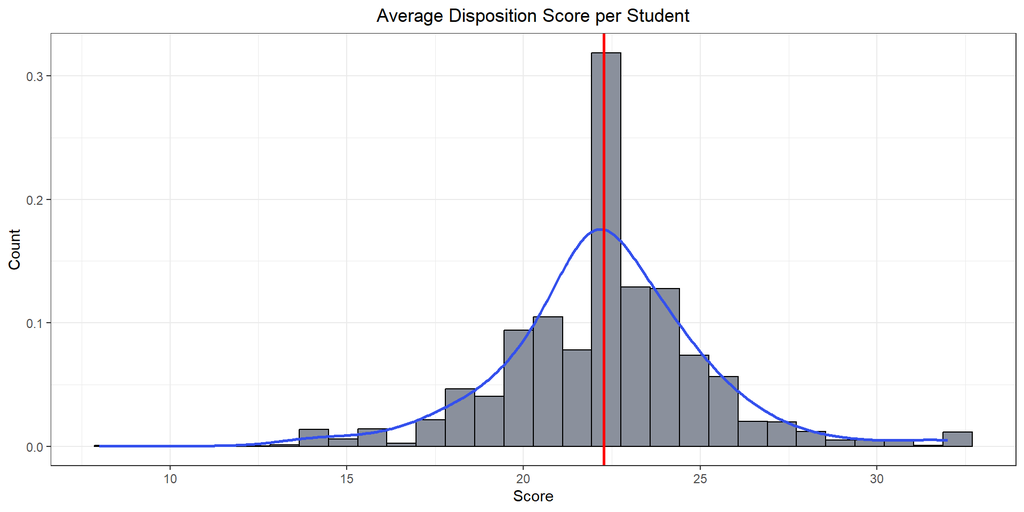

```r
# Find avg score per student.
disp2 <- new_disp |>
  group_by(StudentID) |>
  summarise(avg_score = round(mean(best_score, na.rm = TRUE),2 ))
# Create histogram.
ggplot(disp2, aes(x = avg_score, y = after_stat(density)))+
  geom_histogram(color = "black", fill = "#8a909c")+
  geom_density(color = "#3450ed", linewidth = 1, bw = 1)+
  geom_vline(aes(xintercept=mean(avg_score, na.rm = TRUE)),
            color="red", linetype="solid", size=1)+
  labs(y = "Count",
       x = "Score",
       title = "Average Disposition Score per Student") +
  theme_bw() +
  theme(plot.title = element_text(hjust = 0.5),
        legend.position = "none")
```

```r
#summ2 <- disp1 |>
#  group_by(Class, Code) |>
#  summarise(n = n()) |>
#  mutate(pct= prop.table(n) * 100)

#require(RColorBrewer)
#mycolors = c(brewer.pal(name="Reds", n = 9), brewer.pal(name="Blues", n = 9))

#ggplot(summ2, aes(x = Class, y = pct, fill = Code))+
#  geom_bar(stat = "identity")+
#  coord_flip()+
#  geom_text(aes(label=paste0(sprintf("%1.1f", pct),"%")),
#            position=position_stack(vjust=0.5), size = 4) +
#  labs(title = "Account Opening % by Month and Age",
#       subtitle = "In 2021, excluding <16 and >100",
#       x = "Month",
#       y = "Percentage") +
#  theme_minimal() +
#  theme(
#        plot.title = element_text(hjust = 0.5),
#        plot.subtitle = element_text(hjust = 0.5))

disp1 |>
  group_by(Semester) |>
  summarise(Total_Courses = n(),
            Classes_Taken = sum(total)) |> pander()
```

| Semester | Total_Courses | Classes_Taken |
| --- | --- | --- |
| FA19 | 49 | 2383 |
| FA20 | 56 | 2845 |
| FA21 | 56 | 1102 |
| FA22 | 55 | 991 |
| FA23 | 50 | 770 |
| SP19 | 34 | 1600 |
| SP20 | 26 | 1591 |
| SP21 | 40 | 602 |
| SP22 | 37 | 606 |
| SP23 | 26 | 457 |
| WI19 | 8 | 103 |
| WI20 | 50 | 2192 |
| WI21 | 58 | 2518 |
| WI22 | 52 | 857 |
| WI23 | 54 | 867 |

### Disposition Scores by those with Education Majors

```r
# Get the student information of those found in the full set using the avg disp score.
new_test <- subset(df, (StudentID %in% disp2$StudentID))
View(new_test)
# Join sets.
new_test1 <- new_test |>
  left_join(disp2, by = "StudentID")
# List of student with disp scores that did not transer over.
not_transfer <- subset(disp2, !(StudentID %in% df$StudentID)) #860

#-----------------------------
# Find those with education majors.
major_test <- new_test1 |>
  mutate(school = case_when(
                           str_detect(BachDegreesEarned, "(?i)education|(?i)early | (?i)child ") ~ "education",
                           TRUE ~ "other")) |>
  filter(school == "education")
```

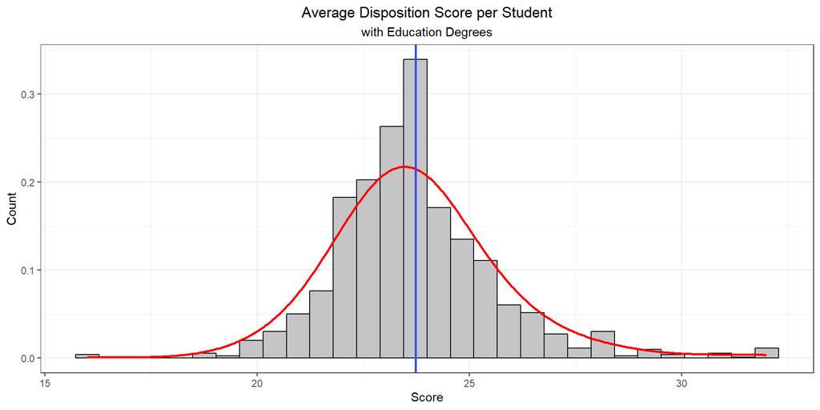

```r
# Find avg score per student for those with education majors.

# Create histogram.
ggplot(major_test, aes(x = avg_score, y = after_stat(density)))+
  geom_histogram(color = "black", fill = "#c5c5c7")+
  geom_density(color = "red", linewidth = 1, bw = 1)+
  geom_vline(aes(xintercept=mean(avg_score, na.rm = TRUE)),
            color="#3450ed", linetype="solid", size=1)+
  labs(y = "Count",
       x = "Score",
       title = "Average Disposition Score per Student",
       subtitle = "with Education Degrees") +
  theme_bw() +
  theme(plot.title = element_text(hjust = 0.5),
        plot.subtitle = element_text(hjust = 0.5),
        legend.position = "none")
```

```r
# Avg score per Semester
major_test |>
  group_by(BachDegreesEarned) |>
  arrange(BachDegreesEarned) |>
  summarise(total = n(),
            avg_best_score = round(mean(avg_score, na.rm = TRUE), 2)) |>
  pander()
```

| BachDegreesEarned | total | avg_best_score |
| --- | --- | --- |
| 730 - Child Development | 28 | 22.85 |
| 736 - Marriage and Fam Studies,980 - Early Child/ Special Ed | 1 | 23.83 |
| 800 - Biology Education | 42 | 24.32 |
| 810 - Chemistry Education | 3 | 24.08 |
| 815 - History Education | 67 | 22.66 |
| 836 - English Education | 52 | 23.13 |
| 840 - Earth Science Education | 4 | 24.03 |
| 850 - Mathematics Education | 11 | 23.97 |
| 852 - Math Education Composite | 59 | 23.42 |
| 860 - Art Education | 15 | 22.4 |
| 862 - Art Education Composite | 58 | 23.08 |
| 870 - Physics Education | 7 | 24.64 |
| 890 - Music Education Composit | 65 | 24.19 |
| 910 - Spanish Education | 61 | 22.96 |
| 935 - Theatre Education | 18 | 22.32 |
| 980 - Early Child/ Special Ed | 126 | 24.17 |
| 985 - Special Education K-12 | 91 | 24.35 |
| 990 - Elementary Education | 553 | 23.92 |